# ПРОЕКТ 5: Анализ бизнес показателей развлекательного приложения Procrastinate Pro+

## Привет!

Я - Сергей. Рад что ты читаешь это текст :) Сделаю пару ремарок общего характера. В описании выполняемых действий, комментариях, я использую местоимение 'мы', так как считаю что ты - ревьювер, проверя код становиться моим соучастником ('соучавствующие программирование') и мы вместе проходим по пути исследования. Да и сформировлась привычка так писать в ходе написания научных работ. NB! - так помечаю важные на мой взгдял идеи, которые стоит взять на заметку; инсайты, проработка которых требует большего знания предметной области. Надеюсь мои многословные комментарии тебя не утомят.

# Оглавление

1. Описание проекта  
2. Загрузка и предобработка данных  
3 Функции для расчёта и анализа LTV, ROI, удержания и конверсии  
3.1 Функция get_profiles() для создания пользовательских профилей  
3.2 Функция get_retention() для расчёта удержания  
3.3 Функция plot_retention() для визуализации удержания  
3.4 Функция get_conversion() для расчёта конверсии  
3.5 Функция plot_conversion() для визуализации конверсии  
3.6 Функция get_ltv() для расчёта LTV и ROI  
3.7 Функции для визуализации LTV и ROI: filter_data() и plot_ltv_roi()  
4 Исследовательский анализ данных  
4.1 Профили пользователей. Минимальная и максимальная дата привлечений пользователей  
4.2 Страновой анализ пользователей  
4.3 Анализ пользователей по используемым устройствам (платформам)  
4.4 Анализ рекламных источников и определение каналов, из которых пришло больше всего платящих пользователей  
4.5 Выводы по разделу  
5 Маркетинг  
5.1 Общая сумма расходов на маркетинг и распеределение трат по каналам  
5.2 Средняя стомость привлечений одного пользователя в разрезе каналов  
5.3 Выводы по разделу  
6 Оценка окупаемости рекламы  
6.1 Анализ общей окупаемости рекламы  
6.2 Анализ окупаемости рекламы в разбивке по рекламным каналам  
6.3 Анализ окупаемости рекламы в разбивке по странам  
6.4 Анализ окупаемости рекламы в разбивке устроуйств (платформ)  
6.5 Промежуточные выводы  
6.6 Графики конверсии и удержания с разбивкой по устройствам, странам, рекламным каналам  
6.7 Выводы по разделу  
7 Общие выводы и рекомендации для отдела маркетинга

## Описание проекта

Вы — маркетинговый аналитик развлекательного приложения Procrastinate Pro+. Несмотря на огромные вложения в рекламу, последние несколько месяцев компания терпит убытки. Ваша задача — разобраться в причинах и помочь компании выйти в плюс.

Есть данные о пользователях, привлечённых с 1 мая по 27 октября 2019 года:

- лог сервера с данными об их посещениях,
- выгрузка их покупок за этот период,
- рекламные расходы.

Вам предстоит изучить:

- откуда приходят пользователи и какими устройствами они пользуются,
- сколько стоит привлечение пользователей из различных рекламных каналов;
- сколько денег приносит каждый клиент,
- когда расходы на привлечение клиента окупаются,
- какие факторы мешают привлечению клиентов.

**Описание данных**

В вашем распоряжении три датасета. Файл `visits_info_short.csv` хранит лог сервера с информацией о посещениях сайта, `orders_info_short.csv` — информацию о покупках, а `costs_info_short.csv` — информацию о расходах на рекламу.

**Структура `visits_info_short.csv`**

- `User Id` — уникальный идентификатор пользователя,
- `Region` — страна пользователя,
- `Device` — тип устройства пользователя,
- `Channel` — идентификатор источника перехода,
- `Session Start` — дата и время начала сессии,
- `Session End` — дата и время окончания сессии.

**Структура `orders_info_short.csv`**

- `User Id` — уникальный идентификатор пользователя,
- `Event Dt` — дата и время покупки,
- `Revenue` — сумма заказа.

**Структура `costs_info_short.csv`**

- `Channel` — идентификатор рекламного источника,
- `Dt` — дата проведения рекламной кампании,
- `Costs` — расходы на эту кампанию.

## Загрузка и предобработка данных

```python
# Импортируем необходимые библиотеки
import pandas as pd
import numpy as np
import time
from datetime import datetime
from datetime import date, datetime, timedelta
from matplotlib import pyplot as plt
#import seaborn as sns
import datetime
```

```python
# Прочитаем файл с гугл диска
from io import BytesIO
import requests
spreadsheet_id_visits = '16-Q1dJGr-Ac4fgA0sEymRrYrxh_thDwU2G2sqo0VWEw'
spreadsheet_id_orders = '1tCS6bseaGZUZoZfHGxnup_zIDIoLS1vMDg8pI8474O4'
spreadsheet_id_costs = '11Y9kJdDHwYoKofnsLj3koZAx-av_5SIOwK1Dy-O4AVI'
file_name_visits = 'https://docs.google.com/spreadsheets/d/{}/export?format=csv'.format(spreadsheet_id_visits)
file_name_orders = 'https://docs.google.com/spreadsheets/d/{}/export?format=csv'.format(spreadsheet_id_orders)
file_name_costs = 'https://docs.google.com/spreadsheets/d/{}/export?format=csv'.format(spreadsheet_id_costs)
r_visits = requests.get(file_name_visits)
r_orders = requests.get(file_name_orders)
r_costs = requests.get(file_name_costs)
visits = pd.read_csv(BytesIO(r_visits.content))
orders = pd.read_csv(BytesIO(r_orders.content))
costs = pd.read_csv(BytesIO(r_costs.content))
```

Выведем информацию обо всех датафремах

```python
display(visits.head()) # журнал визитов
print('-------------------------------------')
visits.info()
```

|  | User Id | Region | Device | Channel | Session Start | Session End |
| --- | --- | --- | --- | --- | --- | --- |
| 0 | 981449118918 | United States | iPhone | organic | 2019-05-01 2:36:01 | 2019-05-01 2:45:01 |
| 1 | 278965908054 | United States | iPhone | organic | 2019-05-01 4:46:31 | 2019-05-01 4:47:35 |
| 2 | 590706206550 | United States | Mac | organic | 2019-05-01 14:09:25 | 2019-05-01 15:32:08 |
| 3 | 326433527971 | United States | Android | TipTop | 2019-05-01 0:29:59 | 2019-05-01 0:54:25 |
| 4 | 349773784594 | United States | Mac | organic | 2019-05-01 3:33:35 | 2019-05-01 3:57:40 |

```
-------------------------------------
<class 'pandas.core.frame.DataFrame'>
RangeIndex: 309901 entries, 0 to 309900
Data columns (total 6 columns):
 #   Column         Non-Null Count   Dtype
---  ------         --------------   -----
 0   User Id        309901 non-null  int64
 1   Region         309901 non-null  object
 2   Device         309901 non-null  object
 3   Channel        309901 non-null  object
 4   Session Start  309901 non-null  object
 5   Session End    309901 non-null  object
dtypes: int64(1), object(5)
memory usage: 14.2+ MB
```

В датафреме visits (визиты) 309 901 наблюдений и 6 колонок, пропущенных значений нет.

```python
display(orders.head())
print('-------------------------------------')
orders.info()
```

|  | User Id | Event Dt | Revenue |
| --- | --- | --- | --- |
| 0 | 188246423999 | 2019-05-01 23:09:52 | 4.99 |
| 1 | 174361394180 | 2019-05-01 12:24:04 | 4.99 |
| 2 | 529610067795 | 2019-05-01 11:34:04 | 4.99 |
| 3 | 319939546352 | 2019-05-01 15:34:40 | 4.99 |
| 4 | 366000285810 | 2019-05-01 13:59:51 | 4.99 |

```
-------------------------------------
<class 'pandas.core.frame.DataFrame'>
RangeIndex: 40212 entries, 0 to 40211
Data columns (total 3 columns):
 #   Column    Non-Null Count  Dtype
---  ------    --------------  -----
 0   User Id   40212 non-null  int64
 1   Event Dt  40212 non-null  object
 2   Revenue   40212 non-null  float64
dtypes: float64(1), int64(1), object(1)
memory usage: 942.6+ KB
```

В датафреме orders (заказы) 40 212 наблюдений и 3 колонки, пропущенных значений нет.

```python
display(costs.head())
print('-------------------------------------')
costs.info()
```

|  | dt | Channel | costs |
| --- | --- | --- | --- |
| 0 | 2019-05-01 | FaceBoom | 113.3 |
| 1 | 2019-05-02 | FaceBoom | 78.1 |
| 2 | 2019-05-03 | FaceBoom | 85.8 |
| 3 | 2019-05-04 | FaceBoom | 136.4 |
| 4 | 2019-05-05 | FaceBoom | 122.1 |

```
-------------------------------------
<class 'pandas.core.frame.DataFrame'>
RangeIndex: 1800 entries, 0 to 1799
Data columns (total 3 columns):
 #   Column   Non-Null Count  Dtype
---  ------   --------------  -----
 0   dt       1800 non-null   object
 1   Channel  1800 non-null   object
 2   costs    1800 non-null   float64
dtypes: float64(1), object(2)
memory usage: 42.3+ KB
```

В датафреме costs (затраты) 1800 наблюдений и 3 колонки, пропущенных значений нет.

**Выводы:**

1. во всех датафремах даты сохранены в формате строк;
2. колонки с текстовыми значениями имют тип объект;
3. колонки названы не в соответсвии с "хорошим тоном".

Наведём порядок.

```python
# Переимениуем колонки: приведём все символы к строчному рееестру и заменим пробемы между слоами на "_"
visits.columns = [x.lower().replace(' ', '_') for x in visits.columns.values]
orders.columns = [x.lower().replace(' ', '_') for x in orders.columns.values]
costs.columns = [x.lower().replace(' ', '_') for x in costs.columns.values]
```

Преобразуем даты к временому типу (datetime), а сроковые колонки к строчном типу (string)

```python
# Датафрейм visits
# Преобразование данных о времени
visits['session_start'] = pd.to_datetime(visits['session_start'])
visits['session_end'] = pd.to_datetime(visits['session_end'])
# Регион, устройство и канал приведем к строковому типу
visits['region'] = visits['region'].astype(str)
visits['device'] = visits['device'].astype(str)
visits['channel'] = visits['channel'].astype(str)
#visits.info()
```

```python
# Датафрейм orders
# Преобразование данных в дату
orders['event_dt'] = pd.to_datetime(orders['event_dt'])
#orders.info()
```

```python
# Датафрейм costs
# Преобразование данных в дату
costs['dt'] = pd.to_datetime(costs['dt'])
#costs.info()
```

**Посмотрим** уникальные значений в колонках датафремов, число наблюдений и описательную статистику по каждому из них (и сделам первые наблюдения), наличие дублирующих записей (дубликатов строк)

```python
# Начнём с датафрема visits
visits['user_id'].value_counts()
```

```
33606575057     46
943775408561    36
901180916748    35
870784569391    34
764086596354    33
                ..
77538669605      1
275054308374     1
466896385517     1
397837182455     1
437337554992     1
Name: user_id, Length: 150008, dtype: int64
```

Пользователь с id 33606575057 заходил аж 46 раз

```python
visits['region'].value_counts()
```

```
United States    207327
UK                36419
France            35396
Germany           30759
Name: region, dtype: int64
```

Больше всего визитов из США

```python
visits['device'].value_counts()
```

```
iPhone     112603
Android     72590
PC          62686
Mac         62022
Name: device, dtype: int64
```

Больше всего визитов с iPhone

```python
visits['channel'].value_counts()
```

```
organic               107760
TipTop                 54794
FaceBoom               49022
WahooNetBanner         20465
LeapBob                17013
OppleCreativeMedia     16794
RocketSuperAds         12724
YRabbit                 9053
MediaTornado            8878
AdNonSense              6891
lambdaMediaAds          6507
Name: channel, dtype: int64
```

Визиты чаще всего "органические" - т.е. пользователи сами находят сайт/ приложение в поисковках/ магазинах приложений и переходят/ скачивают, или преходят по прямым ссылкам.

```python
#visits['session_start'].value_counts() # не показательно
```

```python
#visits['session_end'].value_counts() # не показательно
```

```python
# Проверим дубликаты
visits[visits.duplicated()].count()
```

```
user_id          0
region           0
device           0
channel          0
session_start    0
session_end      0
dtype: int64
```

В датафреме visits дубликатов нет

```python
# Датафрем orders
orders['user_id'].value_counts()
```

```
901180916748    22
883098437811    20
512471511263    19
75337957494     19
295795879965    19
                ..
389231879246     1
550744906785     1
314873470284     1
502292589695     1
775233404832     1
Name: user_id, Length: 8881, dtype: int64
```

Пользователь с id 901180916748 сделал 22 заказа

```python
orders['revenue'].value_counts()
```

```
4.99     38631
5.99       780
9.99       385
49.99      212
19.99      204
Name: revenue, dtype: int64
```

Сумма большинства заказов 4.99$

```python
orders['revenue'].describe()
```

```
count    40212.000000
mean         5.370608
std          3.454208
min          4.990000
25%          4.990000
50%          4.990000
75%          4.990000
max         49.990000
Name: revenue, dtype: float64
```

Средняя сумма заказа 5.37 долл., но медианная (она же минимальная) 4.99 долл. Макcимальная сумма заказа - 49.99 долл. - кто-то взял оптом

```python
#orders['event_dt'].value_counts() # не показательно
```

```python
# Проверим дубликаты
orders[orders.duplicated()].count()
```

```
user_id     0
event_dt    0
revenue     0
dtype: int64
```

В датафреме orders дубликатов нет

```python
# Датафрем costs
costs['channel'].value_counts()
```

```
LeapBob               180
WahooNetBanner        180
FaceBoom              180
MediaTornado          180
YRabbit               180
OppleCreativeMedia    180
RocketSuperAds        180
lambdaMediaAds        180
AdNonSense            180
TipTop                180
Name: channel, dtype: int64
```

Каналы привлечения трафика задейтвованы равномерно

```python
costs['channel'].describe()
```

```
count        1800
unique         10
top       LeapBob
freq          180
Name: channel, dtype: object
```

Всего задейтвано 10 каналов привлечения пользователей

```python
#costs['costs'].value_counts() # не показательно
```

```python
costs['dt'].value_counts()
```

```
2019-08-26    10
2019-07-19    10
2019-10-06    10
2019-08-22    10
2019-07-08    10
              ..
2019-07-27    10
2019-06-12    10
2019-10-14    10
2019-08-30    10
2019-10-10    10
Name: dt, Length: 180, dtype: int64
```

Всего 1800 записей, разбитых на 10 каналов на 180 дат - в датафреме данные за 180 дней

```python
# Проверим дубликаты
costs[costs.duplicated()].count()
```

```
dt         0
channel    0
costs      0
dtype: int64
```

В датафреме costs дубликатов нет

## Функции для расчёта и анализа LTV, ROI, удержания и конверсии

Зададим функции, которые будут необходимы нам для лаьнекйших расчётов и визуализации полученнх даннх

### Функция get_profiles() для создания пользовательских профилей

```python
# Функция get_profiles() для создания пользовательских профилей

def get_profiles(sessions, orders, ad_costs):

    # находим параметры первых посещений
    profiles = (
        sessions.sort_values(by=['user_id', 'session_start'])
        .groupby('user_id')
        .agg(
            {
                'session_start': 'first',
                'channel': 'first',
                'device': 'first',
                'region': 'first',
            }
        )
        .rename(columns={'session_start': 'first_ts'})
        .reset_index()
    )

    # для когортного анализа определяем дату первого посещения
    # и первый день месяца, в который это посещение произошло
    profiles['dt'] = profiles['first_ts'].dt.date
    profiles['dt'] = pd.to_datetime(profiles['dt'], format="%Y-%m-%d")
    profiles['month'] = profiles['first_ts'].astype('datetime64[M]')

    # добавляем признак платящих пользователей
    profiles['payer'] = profiles['user_id'].isin(orders['user_id'].unique())


    # считаем количество уникальных пользователей
    # с одинаковыми источником и датой привлечения
    new_users = (
        profiles.groupby(['dt', 'channel'])
        .agg({'user_id': 'nunique'})
        .rename(columns={'user_id': 'unique_users'})
        .reset_index()
    )

    # объединяем траты на рекламу и число привлечённых пользователей
    ad_costs = ad_costs.merge(new_users, on=['dt', 'channel'], how='left')

    # делим рекламные расходы на число привлечённых пользователей
    ad_costs['acquisition_cost'] = ad_costs['costs'] / ad_costs['unique_users']

    # добавляем стоимость привлечения в профили
    profiles = profiles.merge(
        ad_costs[['dt', 'channel', 'acquisition_cost']],
        on=['dt', 'channel'],
        how='left',
    )

    # стоимость привлечения органических пользователей равна нулю
    profiles['acquisition_cost'] = profiles['acquisition_cost'].fillna(0)

    return profiles
```

### Функция get_retention() для расчёта удержания

```python
# Функция get_retention () для расчёта удержания

def get_retention(
    profiles,
    sessions,
    observation_date,
    horizon_days,
    dimensions=[],
    ignore_horizon=False,
):

    # добавляем столбец payer в передаваемый dimensions список
    dimensions = ['payer'] + dimensions

    # исключаем пользователей, не «доживших» до горизонта анализа
    last_suitable_acquisition_date = observation_date
    if not ignore_horizon:
        last_suitable_acquisition_date = observation_date - timedelta(
            days=horizon_days - 1
        )
    result_raw = profiles.query('dt <= @last_suitable_acquisition_date')

    # собираем «сырые» данные для расчёта удержания
    result_raw = result_raw.merge(
        sessions[['user_id', 'session_start']], on='user_id', how='left'
    )
    result_raw['lifetime'] = (
        result_raw['session_start'] - result_raw['first_ts']
    ).dt.days

    # функция для группировки таблицы по желаемым признакам
    def group_by_dimensions(df, dims, horizon_days):
        result = df.pivot_table(
            index=dims, columns='lifetime', values='user_id', aggfunc='nunique'
        )
        cohort_sizes = (
            df.groupby(dims)
            .agg({'user_id': 'nunique'})
            .rename(columns={'user_id': 'cohort_size'})
        )
        result = cohort_sizes.merge(result, on=dims, how='left').fillna(0)
        result = result.div(result['cohort_size'], axis=0)
        result = result[['cohort_size'] + list(range(horizon_days))]
        result['cohort_size'] = cohort_sizes
        return result

    # получаем таблицу удержания
    result_grouped = group_by_dimensions(result_raw, dimensions, horizon_days)

    # получаем таблицу динамики удержания
    result_in_time = group_by_dimensions(
        result_raw, dimensions + ['dt'], horizon_days
    )

    # возвращаем обе таблицы и сырые данные
    return result_raw, result_grouped, result_in_time
```

### Функция plot_retention() для визуализации удержания

```python
# Функция plot_retention() для визуализации удержания
def plot_retention(retention, retention_history, horizon, window=7):

    # задаём размер сетки для графиков
    plt.figure(figsize=(15, 10))

    # исключаем размеры когорт и удержание первого дня
    retention = retention.drop(columns=['cohort_size', 0])
    # в таблице динамики оставляем только нужный лайфтайм
    retention_history = retention_history.drop(columns=['cohort_size'])[
        [horizon - 1]
    ]

    # если в индексах таблицы удержания только payer,
    # добавляем второй признак — cohort
    if retention.index.nlevels == 1:
        retention['cohort'] = 'All users'
        retention = retention.reset_index().set_index(['cohort', 'payer'])

    # в таблице графиков — два столбца и две строки, четыре ячейки
    # в первой строим кривые удержания платящих пользователей
    ax1 = plt.subplot(2, 2, 1)
    retention.query('payer == True').droplevel('payer').T.plot(
        grid=True, ax=ax1
    )
    plt.legend()
    plt.xlabel('Лайфтайм')
    plt.title('Удержание платящих пользователей')

    # во второй ячейке строим кривые удержания неплатящих
    # вертикальная ось — от графика из первой ячейки
    ax2 = plt.subplot(2, 2, 2, sharey=ax1)
    retention.query('payer == False').droplevel('payer').T.plot(
        grid=True, ax=ax2
    )
    plt.legend()
    plt.xlabel('Лайфтайм')
    plt.title('Удержание неплатящих пользователей')

    # в третьей ячейке — динамика удержания платящих
    ax3 = plt.subplot(2, 2, 3)
    # получаем названия столбцов для сводной таблицы
    columns = [
        name
        for name in retention_history.index.names
        if name not in ['dt', 'payer']
    ]
    # фильтруем данные и строим график
    filtered_data = retention_history.query('payer == True').pivot_table(
        index='dt', columns=columns, values=horizon - 1, aggfunc='mean'
    )
    filter_data(filtered_data, window).plot(grid=True, ax=ax3)
    plt.xlabel('Дата привлечения')
    plt.title(
        'Динамика удержания платящих пользователей на {}-й день'.format(
            horizon
        )
    )

    # в чётвертой ячейке — динамика удержания неплатящих
    ax4 = plt.subplot(2, 2, 4, sharey=ax3)
    # фильтруем данные и строим график
    filtered_data = retention_history.query('payer == False').pivot_table(
        index='dt', columns=columns, values=horizon - 1, aggfunc='mean'
    )
    filter_data(filtered_data, window).plot(grid=True, ax=ax4)
    plt.xlabel('Дата привлечения')
    plt.title(
        'Динамика удержания неплатящих пользователей на {}-й день'.format(
            horizon
        )
    )

    plt.tight_layout()
    plt.show()
```

### Функция get_conversion() для расчёта конверсии

```python
# Функция get_conversion() для расчёта конверсии

def get_conversion(
    profiles,
    purchases,
    observation_date,
    horizon_days,
    dimensions=[],
    ignore_horizon=False,
):

    # исключаем пользователей, не «доживших» до горизонта анализа
    last_suitable_acquisition_date = observation_date
    if not ignore_horizon:
        last_suitable_acquisition_date = observation_date - timedelta(
            days=horizon_days - 1
        )
    result_raw = profiles.query('dt <= @last_suitable_acquisition_date')

    # определяем дату и время первой покупки для каждого пользователя
    first_purchases = (
        purchases.sort_values(by=['user_id', 'event_dt'])
        .groupby('user_id')
        .agg({'event_dt': 'first'})
        .reset_index()
    )

    # добавляем данные о покупках в профили
    result_raw = result_raw.merge(
        first_purchases[['user_id', 'event_dt']], on='user_id', how='left'
    )

    # рассчитываем лайфтайм для каждой покупки
    result_raw['lifetime'] = (
        result_raw['event_dt'] - result_raw['first_ts']
    ).dt.days

    # группируем по cohort, если в dimensions ничего нет
    if len(dimensions) == 0:
        result_raw['cohort'] = 'All users'
        dimensions = dimensions + ['cohort']

    # функция для группировки таблицы по желаемым признакам
    def group_by_dimensions(df, dims, horizon_days):
        result = df.pivot_table(
            index=dims, columns='lifetime', values='user_id', aggfunc='nunique'
        )
        result = result.fillna(0).cumsum(axis = 1)
        cohort_sizes = (
            df.groupby(dims)
            .agg({'user_id': 'nunique'})
            .rename(columns={'user_id': 'cohort_size'})
        )
        result = cohort_sizes.merge(result, on=dims, how='left').fillna(0)
        # делим каждую «ячейку» в строке на размер когорты
        # и получаем conversion rate
        result = result.div(result['cohort_size'], axis=0)
        result = result[['cohort_size'] + list(range(horizon_days))]
        result['cohort_size'] = cohort_sizes
        return result

    # получаем таблицу конверсии
    result_grouped = group_by_dimensions(result_raw, dimensions, horizon_days)

    # для таблицы динамики конверсии убираем 'cohort' из dimensions
    if 'cohort' in dimensions:
        dimensions = []

    # получаем таблицу динамики конверсии
    result_in_time = group_by_dimensions(
        result_raw, dimensions + ['dt'], horizon_days
    )

    # возвращаем обе таблицы и сырые данные
    return result_raw, result_grouped, result_in_time
```

### Функция plot_conversion() для визуализации конверсии

```python
# Функция plot_conversion() для визуализации конверсии

def plot_conversion(conversion, conversion_history, horizon, window=7):

    # задаём размер сетки для графиков
    plt.figure(figsize=(15, 5))

    # исключаем размеры когорт
    conversion = conversion.drop(columns=['cohort_size'])
    # в таблице динамики оставляем только нужный лайфтайм
    conversion_history = conversion_history.drop(columns=['cohort_size'])[
        [horizon - 1]
    ]

    # первый график — кривые конверсии
    ax1 = plt.subplot(1, 2, 1)
    conversion.T.plot(grid=True, ax=ax1)
    plt.legend()
    plt.xlabel('Лайфтайм')
    plt.title('Конверсия пользователей')

    # второй график — динамика конверсии
    ax2 = plt.subplot(1, 2, 2, sharey=ax1)
    columns = [
        # столбцами сводной таблицы станут все столбцы индекса, кроме даты
        name for name in conversion_history.index.names if name not in ['dt']
    ]
    filtered_data = conversion_history.pivot_table(
        index='dt', columns=columns, values=horizon - 1, aggfunc='mean'
    )
    filter_data(filtered_data, window).plot(grid=True, ax=ax2)
    plt.xlabel('Дата привлечения')
    plt.title('Динамика конверсии пользователей на {}-й день'.format(horizon))

    plt.tight_layout()
    plt.show()
```

### Функция get_ltv() для расчёта LTV и ROI

```python
# Функция get_ltv() для расчёта LTV и ROI

def get_ltv(
    profiles,
    purchases,
    observation_date,
    horizon_days,
    dimensions=[],
    ignore_horizon=False,
):

    # исключаем пользователей, не «доживших» до горизонта анализа
    last_suitable_acquisition_date = observation_date
    if not ignore_horizon:
        last_suitable_acquisition_date = observation_date - timedelta(
            days=horizon_days - 1
        )
    result_raw = profiles.query('dt <= @last_suitable_acquisition_date')
    # добавляем данные о покупках в профили
    result_raw = result_raw.merge(
        purchases[['user_id', 'event_dt', 'revenue']], on='user_id', how='left'
    )
    # рассчитываем лайфтайм пользователя для каждой покупки
    result_raw['lifetime'] = (
        result_raw['event_dt'] - result_raw['first_ts']
    ).dt.days
    # группируем по cohort, если в dimensions ничего нет
    if len(dimensions) == 0:
        result_raw['cohort'] = 'All users'
        dimensions = dimensions + ['cohort']

    # функция группировки по желаемым признакам
    def group_by_dimensions(df, dims, horizon_days):
        # строим «треугольную» таблицу выручки
        result = df.pivot_table(
            index=dims, columns='lifetime', values='revenue', aggfunc='sum'
        )
        # находим сумму выручки с накоплением
        result = result.fillna(0).cumsum(axis=1)
        # вычисляем размеры когорт
        cohort_sizes = (
            df.groupby(dims)
            .agg({'user_id': 'nunique'})
            .rename(columns={'user_id': 'cohort_size'})
        )
        # объединяем размеры когорт и таблицу выручки
        result = cohort_sizes.merge(result, on=dims, how='left').fillna(0)
        # считаем LTV: делим каждую «ячейку» в строке на размер когорты
        result = result.div(result['cohort_size'], axis=0)
        # исключаем все лайфтаймы, превышающие горизонт анализа
        result = result[['cohort_size'] + list(range(horizon_days))]
        # восстанавливаем размеры когорт
        result['cohort_size'] = cohort_sizes

        # что мы здесь делаем???
        cac = df[['user_id', 'acquisition_cost'] + dims].drop_duplicates()

        # считаем средний CAC по параметрам из dimensions
        cac = (
            cac.groupby(dims)
            .agg({'acquisition_cost': 'mean'})
            .rename(columns={'acquisition_cost': 'cac'})
        )

        # считаем ROI: делим LTV на CAC
        roi = result.div(cac['cac'], axis=0)

        # удаляем строки с бесконечным ROI
        roi = roi[~roi['cohort_size'].isin([np.inf])]

        # восстанавливаем размеры когорт в таблице ROI
        roi['cohort_size'] = cohort_sizes

        # добавляем CAC в таблицу ROI
        roi['cac'] = cac['cac']

        # в финальной таблице оставляем размеры когорт, CAC
        # и ROI в лайфтаймы, не превышающие горизонт анализа
        roi = roi[['cohort_size', 'cac'] + list(range(horizon_days))]

        # возвращаем таблицы LTV и ROI
        return result, roi

    # получаем таблицы LTV и ROI
    result_grouped, roi_grouped = group_by_dimensions(
        result_raw, dimensions, horizon_days
    )

    # для таблиц динамики убираем 'cohort' из dimensions
    if 'cohort' in dimensions:
        dimensions = []

    # получаем таблицы динамики LTV и ROI
    result_in_time, roi_in_time = group_by_dimensions(
        result_raw, dimensions + ['dt'], horizon_days
    )

    return (
        result_raw,  # сырые данные
        result_grouped,  # таблица LTV
        result_in_time,  # таблица динамики LTV
        roi_grouped,  # таблица ROI
        roi_in_time,  # таблица динамики ROI
    )
```

### Функции для визуализации LTV и ROI: filter_data() и plot_ltv_roi()

```python
# Функция filter_data() для сглаживания фрейма

def filter_data(df, window):
    # для каждого столбца применяем скользящее среднее
    for column in df.columns.values:
        df[column] = df[column].rolling(window).mean()
    return df
```

```python
# Функция plot_ltv_roi() для визуализации LTV и ROI

def plot_ltv_roi(ltv, ltv_history, roi, roi_history, horizon, window=7):

    # задаём сетку отрисовки графиков
    plt.figure(figsize=(20, 10))

    # из таблицы ltv исключаем размеры когорт
    ltv = ltv.drop(columns=['cohort_size'])
    # в таблице динамики ltv оставляем только нужный лайфтайм
    ltv_history = ltv_history.drop(columns=['cohort_size'])[[horizon - 1]]

    # стоимость привлечения запишем в отдельный фрейм
    cac_history = roi_history[['cac']]

    # из таблицы roi исключаем размеры когорт и cac
    roi = roi.drop(columns=['cohort_size', 'cac'])
    # в таблице динамики roi оставляем только нужный лайфтайм
    roi_history = roi_history.drop(columns=['cohort_size', 'cac'])[
        [horizon - 1]
    ]

    # первый график — кривые ltv
    ax1 = plt.subplot(2, 3, 1)
    ltv.T.plot(grid=True, ax=ax1)
    plt.legend()
    plt.xlabel('Лайфтайм')
    plt.title('LTV')

    # второй график — динамика ltv
    ax2 = plt.subplot(2, 3, 2, sharey=ax1)
    # столбцами сводной таблицы станут все столбцы индекса, кроме даты
    columns = [name for name in ltv_history.index.names if name not in ['dt']]
    filtered_data = ltv_history.pivot_table(
        index='dt', columns=columns, values=horizon - 1, aggfunc='mean'
    )
    filter_data(filtered_data, window).plot(grid=True, ax=ax2)
    plt.xlabel('Дата привлечения')
    plt.title('Динамика LTV пользователей на {}-й день'.format(horizon))

    # третий график — динамика cac
    ax3 = plt.subplot(2, 3, 3, sharey=ax1)
    # столбцами сводной таблицы станут все столбцы индекса, кроме даты
    columns = [name for name in cac_history.index.names if name not in ['dt']]
    filtered_data = cac_history.pivot_table(
        index='dt', columns=columns, values='cac', aggfunc='mean'
    )
    filter_data(filtered_data, window).plot(grid=True, ax=ax3)
    plt.xlabel('Дата привлечения')
    plt.title('Динамика стоимости привлечения пользователей')

    # четвёртый график — кривые roi
    ax4 = plt.subplot(2, 3, 4)
    roi.T.plot(grid=True, ax=ax4)
    plt.axhline(y=1, color='red', linestyle='--', label='Уровень окупаемости')
    plt.legend()
    plt.xlabel('Лайфтайм')
    plt.title('ROI')

    # пятый график — динамика roi
    ax5 = plt.subplot(2, 3, 5, sharey=ax4)
    # столбцами сводной таблицы станут все столбцы индекса, кроме даты
    columns = [name for name in roi_history.index.names if name not in ['dt']]
    filtered_data = roi_history.pivot_table(
        index='dt', columns=columns, values=horizon - 1, aggfunc='mean'
    )
    filter_data(filtered_data, window).plot(grid=True, ax=ax5)
    plt.axhline(y=1, color='red', linestyle='--', label='Уровень окупаемости')
    plt.xlabel('Дата привлечения')
    plt.title('Динамика ROI пользователей на {}-й день'.format(horizon))

    plt.tight_layout()
    plt.show()
```

## Исследовательский анализ данных

### Профили пользователей. Минимальная и максимальная дата привлечений пользователей

```python
# Получим профили пользователей - вызовем функцию get_profiles(), передав ей данные о посещениях, покупках и тратах на рекламу
profiles = get_profiles(visits, orders, costs)
display(profiles.head())
```

|  | user_id | first_ts | channel | device | region | dt | month | payer | acquisition_cost |
| --- | --- | --- | --- | --- | --- | --- | --- | --- | --- |
| 0 | 599326 | 2019-05-07 20:58:57 | FaceBoom | Mac | United States | 2019-05-07 | 2019-05-01 | True | 1.088172 |
| 1 | 4919697 | 2019-07-09 12:46:07 | FaceBoom | iPhone | United States | 2019-07-09 | 2019-07-01 | False | 1.107237 |
| 2 | 6085896 | 2019-10-01 09:58:33 | organic | iPhone | France | 2019-10-01 | 2019-10-01 | False | 0.000000 |
| 3 | 22593348 | 2019-08-22 21:35:48 | AdNonSense | PC | Germany | 2019-08-22 | 2019-08-01 | False | 0.988235 |
| 4 | 31989216 | 2019-10-02 00:07:44 | YRabbit | iPhone | United States | 2019-10-02 | 2019-10-01 | False | 0.230769 |

```python
# Определим минимальную и максимальную даты привлечения пользователей
min_analysis_date = profiles['dt'].min() # доступный интервал привлечения пользователей
observation_date = profiles['dt'].max()  # момент анализа
print('Доступный интервал привлечения пользователей:', min_analysis_date)
print('Момент анализа:', observation_date)
```

```
Доступный интервал привлечения пользователей: 2019-05-01 00:00:00
Момент анализа: 2019-10-27 00:00:00
```

Для анализа доступны данные с 1 мая по 27 октября 2019 года

### Страновой анализ пользователей

```python
# Построим таблицу, отражающую количество и долю пользователей из каждой страны
print('Число и доля пользователей в разрезе стран')
region_share = pd.DataFrame()
region_share['users_cnt'] = profiles.groupby('region')['user_id'].count() # Число пользователей
region_share['share'] = ((region_share['users_cnt'] / profiles['region'].count()) * 100) # Их доля в общем числе пользователей
region_share.sort_values(by='share', ascending=False).style.format({'share': '{:.2f}%'})
```

```
Число и доля пользователей в разрезе стран
```

| region | users_cnt | share |
| --- | --- | --- |
| United States | 100002 | 66.66% |
| UK | 17575 | 11.72% |
| France | 17450 | 11.63% |
| Germany | 14981 | 9.99% |

```python
# Построим таблицу, отражающую количество и долю платящих пользователей из каждой страны
print('Число и доля платящих пользователей в разрезе стран')
region_payer_share = pd.DataFrame()
region_payer_share['users_cnt'] = profiles.query('payer == True').groupby('region')['user_id'].count() # Число пользователей
region_payer_share['share'] = ((region_payer_share['users_cnt'] / profiles.query('payer == True')['region'].count()) * 100) # Их доля в общем числе пользователей
region_payer_share.sort_values(by='share', ascending=False).style.format({'share': '{:.2f}%'})
```

```
Число и доля платящих пользователей в разрезе стран
```

| region | users_cnt | share |
| --- | --- | --- |
| United States | 6902 | 77.72% |
| UK | 700 | 7.88% |
| France | 663 | 7.47% |
| Germany | 616 | 6.94% |

```python
# Рассчитаем долю платящих пользователей отдельно по странам
# от общего числа пользоватей в каждой из стран
print('Число и доля платящих пользователей в каждой из стран')
def pivot_share_result(column, df):
    result = pd.DataFrame()
    result['users_cnt'] = df.groupby(column)['user_id'].count()
    result['users_share'] = ((result['users_cnt'] / df[column].count()) * 100)
    result['payer_users_cnt'] = df.query('payer == True').groupby(column)['user_id'].count()
    result['payer_share'] = ((result['payer_users_cnt'] / result['users_cnt']) * 100)
    return result.sort_values(by='users_share', ascending=False).style.format({'users_share': '{:.2f}%', 'payer_share': '{:.2f}%'})
pivot_share_result('region', profiles)
```

```
Число и доля платящих пользователей в каждой из стран
```

| region | users_cnt | users_share | payer_users_cnt | payer_share |
| --- | --- | --- | --- | --- |
| United States | 100002 | 66.66% | 6902 | 6.90% |
| UK | 17575 | 11.72% | 700 | 3.98% |
| France | 17450 | 11.63% | 663 | 3.80% |
| Germany | 14981 | 9.99% | 616 | 4.11% |

Большинство пользователей, как в целом, так и платящих, из США: в общем числе пользователей доля пользователей из США составляет 2/3, среди платящих – 77,7%. Среди пользователей из США самая большая доля платящих – 6,9%, то есть платит почти каждый 15-й пользователь из США, что почти двое больше чем в других странах.

### Анализ пользователей по используемым устройствам (платформам)

```python
# Построим таблицу, отражающую количество и долю пользователей на каждой из платаформ
print('Число и доля пользователей каждой из платформ')
device_share = pd.DataFrame()
device_share['users_cnt'] = profiles.groupby('device')['user_id'].count() # Число пользователей
device_share['share'] = ((device_share['users_cnt'] / profiles['device'].count()) * 100) # Их доля в общем числе пользователей
device_share.sort_values(by='share', ascending=False).style.format({'share': '{:.2f}%'})
```

```
Число и доля пользователей каждой из платформ
```

| device | users_cnt | share |
| --- | --- | --- |
| iPhone | 54479 | 36.32% |
| Android | 35032 | 23.35% |
| PC | 30455 | 20.30% |
| Mac | 30042 | 20.03% |

```python
# Построим таблицу, отражающую количество и долю платящих пользователей на каждой из платаформ
print('Число и доля платящих пользователей каждой из платформ')
device_payer_share = pd.DataFrame()
device_payer_share['users_cnt'] = profiles.query('payer == True').groupby('device')['user_id'].count() # Число пользователей
device_payer_share['share'] = ((device_payer_share['users_cnt'] / profiles.query('payer == True')['device'].count()) * 100) # Их доля в общем числе пользователей
device_payer_share.sort_values(by='share', ascending=False).style.format({'share': '{:.2f}%'})
```

```
Число и доля платящих пользователей каждой из платформ
```

| device | users_cnt | share |
| --- | --- | --- |
| iPhone | 3382 | 38.08% |
| Android | 2050 | 23.08% |
| Mac | 1912 | 21.53% |
| PC | 1537 | 17.31% |

```python
# Используем функцию и рассчитаем долю платящих пользователей отдельно по платформам
# от общего числа пользоватей каждой платформы
print('Число и доля платящих пользователей на каждой из платформ')
pivot_share_result('device', profiles)
```

```
Число и доля платящих пользователей на каждой из платформ
```

| device | users_cnt | users_share | payer_users_cnt | payer_share |
| --- | --- | --- | --- | --- |
| iPhone | 54479 | 36.32% | 3382 | 6.21% |
| Android | 35032 | 23.35% | 2050 | 5.85% |
| PC | 30455 | 20.30% | 1537 | 5.05% |
| Mac | 30042 | 20.03% | 1912 | 6.36% |

### Анализ рекламных источников и определение каналов, из которых пришло больше всего платящих пользователей

```python
# Подсчитаем число и долю пользователей/ платящих пользователей, в разрезе каналов привлечения
print('Число и доля пользователей/ платящих пользователей, в разрезе каналов привлечения')
channel_share = pd.DataFrame()
channel_share['users_cnt'] = profiles.groupby('channel')['user_id'].count()
channel_share['share'] = ((channel_share['users_cnt'] / profiles['channel'].count()) * 100)

channel_share['payer_users_cnt'] = profiles.query('payer == True').groupby('channel')['user_id'].count()
channel_share['payer_share'] = ((channel_share['payer_users_cnt'] / profiles.query('payer == True')['channel'].count()) * 100)

channel_share.sort_values(by='share', ascending=False).style.format({'share': '{:.2f}%', 'payer_share': '{:.2f}%'})
```

```
Число и доля пользователей/ платящих пользователей, в разрезе каналов привлечения
```

| channel | users_cnt | share | payer_users_cnt | payer_share |
| --- | --- | --- | --- | --- |
| organic | 56439 | 37.62% | 1160 | 13.06% |
| FaceBoom | 29144 | 19.43% | 3557 | 40.05% |
| TipTop | 19561 | 13.04% | 1878 | 21.15% |
| OppleCreativeMedia | 8605 | 5.74% | 233 | 2.62% |
| LeapBob | 8553 | 5.70% | 262 | 2.95% |
| WahooNetBanner | 8553 | 5.70% | 453 | 5.10% |
| RocketSuperAds | 4448 | 2.97% | 352 | 3.96% |
| MediaTornado | 4364 | 2.91% | 156 | 1.76% |
| YRabbit | 4312 | 2.87% | 165 | 1.86% |
| AdNonSense | 3880 | 2.59% | 440 | 4.95% |
| lambdaMediaAds | 2149 | 1.43% | 225 | 2.53% |

```python
# Рассчитаем долю платящих пользователей отдельно по каждому из каналов
print('Число и доля платящих пользователей по каждому из каналов привлечения')
pivot_share_result('channel', profiles)
```

```
Число и доля платящих пользователей по каждому из каналов привлечения
```

| channel | users_cnt | users_share | payer_users_cnt | payer_share |
| --- | --- | --- | --- | --- |
| organic | 56439 | 37.62% | 1160 | 2.06% |
| FaceBoom | 29144 | 19.43% | 3557 | 12.20% |
| TipTop | 19561 | 13.04% | 1878 | 9.60% |
| OppleCreativeMedia | 8605 | 5.74% | 233 | 2.71% |
| LeapBob | 8553 | 5.70% | 262 | 3.06% |
| WahooNetBanner | 8553 | 5.70% | 453 | 5.30% |
| RocketSuperAds | 4448 | 2.97% | 352 | 7.91% |
| MediaTornado | 4364 | 2.91% | 156 | 3.57% |
| YRabbit | 4312 | 2.87% | 165 | 3.83% |
| AdNonSense | 3880 | 2.59% | 440 | 11.34% |
| lambdaMediaAds | 2149 | 1.43% | 225 | 10.47% |

### Выводы по разделу

Для анализа доступны данные с 1 мая по 27 октября 2019 года.

## Маркетинг

### Общая сумма расходов на маркетинг и распеределение трат по каналам

```python
# Подсчистем суммарные затраты на маркетинг
# она скорее всего в $. так как траты пользоватей очень позожи на чены на приложения в $
print('Общая сумма расходов на маркетинг составила', costs['costs'].sum().round(1), '$')
```

```
Общая сумма расходов на маркетинг составила 105497.3 $
```

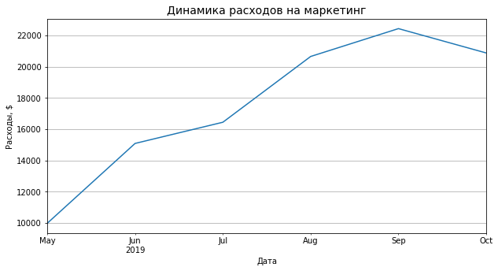

```python
#  Вытащим из колонки 'dt' в месяц
costs['month'] = costs['dt'].astype('datetime64[M]')
# Сгруппируем затраты по месяцам и визуализируем
costs.pivot_table(index='month', values='costs', aggfunc='sum'
                                    ).plot(grid=True, figsize=(10, 5), legend=False)
plt.title('Динамика расходов на маркетинг',fontsize=14)
plt.xlabel('Дата',fontsize=10)
plt.ylabel('Расходы, $',fontsize=10)
plt.show();
```

Расходы на маркетинг росли, но в октябре снизились - возможно потому, что данные не за весь месяц.

```python
# Посмотрим распеределение трат по каналам
channel_costs_report = pd.DataFrame()
channel_costs_report['costs'] = costs.groupby('channel')['costs'].sum() # Сумма расходов
channel_costs_report['share'] = ((channel_costs_report['costs'] / costs['costs'].sum()) * 100) # Доля в обшей сумме расходов
channel_costs_report.sort_values(by='share', ascending=False).style.format({'share': '{:.2f}%', 'payer_share': '{:.2f}%'})
```

| channel | costs | share |
| --- | --- | --- |
| TipTop | 54751.300000 | 51.90% |
| FaceBoom | 32445.600000 | 30.75% |
| WahooNetBanner | 5151.000000 | 4.88% |
| AdNonSense | 3911.250000 | 3.71% |
| OppleCreativeMedia | 2151.250000 | 2.04% |
| RocketSuperAds | 1833.000000 | 1.74% |
| LeapBob | 1797.600000 | 1.70% |
| lambdaMediaAds | 1557.600000 | 1.48% |
| MediaTornado | 954.480000 | 0.90% |
| YRabbit | 944.220000 | 0.90% |

Почти 52% маркетинговых затрат приходится на канал TipTop, на втрой по объёму затрат канал FaceBoom прихрдится 30,8% маркетингового бюджета.

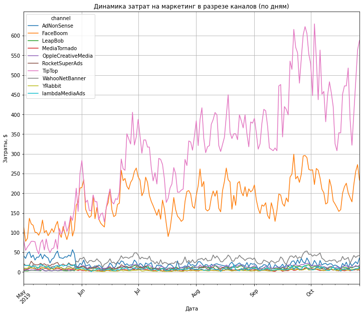

```python
# Сгруппируем затраты по каналам и визуализируем динамику трат в разрезе каналов по дням
pivot_costs = costs.pivot_table(index='dt', columns='channel', values='costs', aggfunc='sum')
pivot_costs.plot(figsize=(12, 10), grid=True, rot=45, label='Каналы',legend=True)
plt.yticks(np.arange(0, 650, 50)) #зададим шаг на оси Y
plt.title('Динамика затрат на маркетинг в разрезе каналов (по дням)')
plt.xlabel('Дата')
plt.ylabel('Затраты, $')
plt.show()
```

Динамичнее всего наращивали маркетинговый бюджет на каналы TipTop и FaceBoom. Отальные каналы имеют малую долю и почти не различимы на графике, рассмотрим их отдельно.

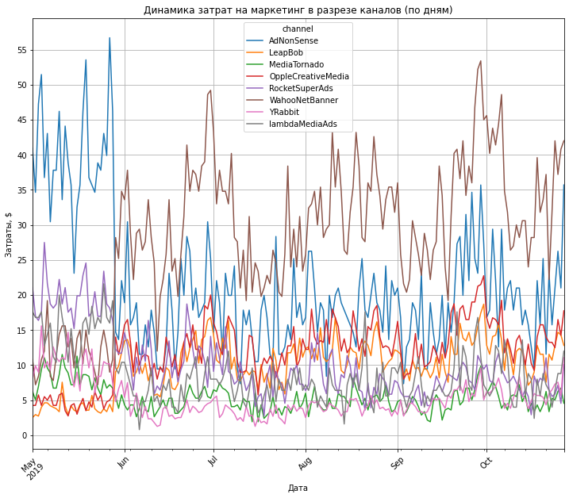

```python
# исключим каналы TipTop и FaceBoom и посмотрим на динамку минорных каналов
pivot_costs_filtered = costs[~costs['channel'].isin(['TipTop', 'FaceBoom'])].pivot_table(
        index='dt', columns='channel', values='costs', aggfunc='sum')

pivot_costs_filtered .plot(
           figsize=(12, 10),
           grid=True,
           rot=45,
           label='Каналы',
           legend=True)

plt.yticks(np.arange(0,  60, 5))#зададим шаг на оси Y
plt.title('Динамика затрат на маркетинг в разрезе каналов (по дням)')
plt.xlabel('Дата')
plt.ylabel('Затраты, $')
plt.show()
```

С июня начали расти траты на WahooNetBanner, а затраты на канал AdNonSense, наоборот начали в июне снижатся.

### Средняя стомость привлечений одного пользователя в разрезе каналов

Используя профили пользоватетелй рассчитаем средний CAC на одного пользователя для всего проекта и для каждого источника трафика.

```python
# Обратимся к дататфрему profiles и узнаем средюю и меданную стомость привлечений одного пользователя (колонки acquisition_cost)
profiles['acquisition_cost'].describe()
```

```
count    150008.000000
mean          0.703278
std           0.954097
min           0.000000
25%           0.000000
50%           0.247500
75%           1.108943
max           3.715385
Name: acquisition_cost, dtype: float64
```

Средняя стомость привлечений одного пользователя - 0.7 долл., медианная - 0.24 долл. **Гипотеза** причина столь резкого различия в органичеких пользователях, на медану они вляют, а деньги нах привлечений не тратились. Проверим гипотезу, посмотрм распределений трат.

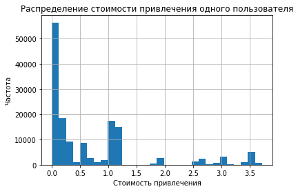

```python
profiles['acquisition_cost'].hist(bins=30)
plt.title('Распределение стоимости привлечения одного пользователя')
plt.xlabel('Стоимость привлечения')
plt.ylabel('Частота')
plt.show()
```

Да, большое число пользователей с нулевой стомостью привлечений (органические пользователи) точно оказывают влияние на медианну.

```python
# Исключим пользователей с органическим трафиком
profiles = profiles.query('channel != "organic"')
# Посмотрим как это повлияло на средние и медиану
profiles['acquisition_cost'].describe()
```

```
count    93569.000000
mean         1.127481
std          0.990503
min          0.124615
25%          0.257143
50%          1.080531
75%          1.128571
max          3.715385
Name: acquisition_cost, dtype: float64
```

И среднее и медиана 'подросли', до 1.13 долл. и 1.08 долл. соответственно

```python
#Расчитаем CAC в разрезе каналов
cac_by_channel = pd.DataFrame()
cac_by_channel['acquisition_cost_mean'] = profiles.groupby('channel')['acquisition_cost'].mean()
cac_by_channel.sort_values(by='acquisition_cost_mean', ascending=False).style.format({'acquisition_cost_mean': '{:.2f}'})
display(cac_by_channel)
```

| channel | acquisition_cost_mean |
| --- | --- |
| AdNonSense | 1.008054 |
| FaceBoom | 1.113286 |
| LeapBob | 0.210172 |
| MediaTornado | 0.218717 |
| OppleCreativeMedia | 0.250000 |
| RocketSuperAds | 0.412095 |
| TipTop | 2.799003 |
| WahooNetBanner | 0.602245 |
| YRabbit | 0.218975 |
| lambdaMediaAds | 0.724802 |

```
CAC в разрезе каналов
```

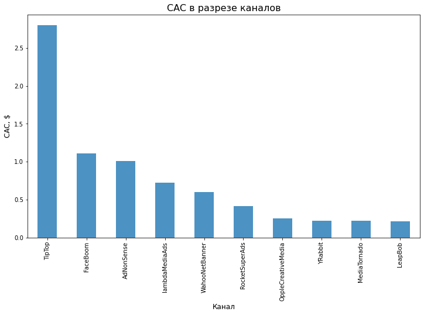

```python
# Визуализурем данные
cac_by_channel.sort_values(by='acquisition_cost_mean', ascending=False).plot(y='acquisition_cost_mean', kind='bar', figsize=(12, 7), legend=False, alpha=0.8)
plt.title(label='CAC в разрезе каналов', fontsize=16)
plt.xlabel('Канал', fontsize=12)
plt.ylabel('CAC, $', fontsize=12)
print('CAC в разрезе каналов')
```

Заметно выше средней стоимости цена привлечений одного пользователя через каналы TipTop (почти 2.8 долл.). У каналоа FaceBoom стоимость привлечений чуть ниже среднего(1.11 долл.), а замыкает тройку 'дорогих' каналов AdNonSens (1,01 долл.), Привлечение одного пользователя через остальные каналы стоит заметно меньше средней стоимости привлечения.

## Оценка окупаемости рекламы

Для дальнешего анализа мы:

1. Установим момент анализа (observation_date) - 1 ноября 2019 года.
2. Установим горизонт анализа (horizon_days) - 14 дней.
3. Исключим из анализа пользователей с органическим трафиком - затрат на из првлечени нет, но их присутвие при оценке эффективности рекламы сформурует более "позитивную", чем есть в реальности, картину окупаемости рекламного бюджета - пользователь будет больше, а затраты на каждого из них следовательно меньше.

```python
observation_date = datetime.datetime(2019, 11, 1).date() # Момент анализа - 01.11.2019
horizon_days = 14 # Горизонт анализа - 14 дней
```

```python
# Исключим пользователей с органическим трафиком
profiles = profiles.query('channel != "organic"')
```

### Анализ общей окупаемости рекламы

Вызовим функцию get_ltv, расчитаем метрики, а после построим графики LTV и ROI, а также графики динамики LTV, CAC и ROI с помощью функии plot_ltv_roi.

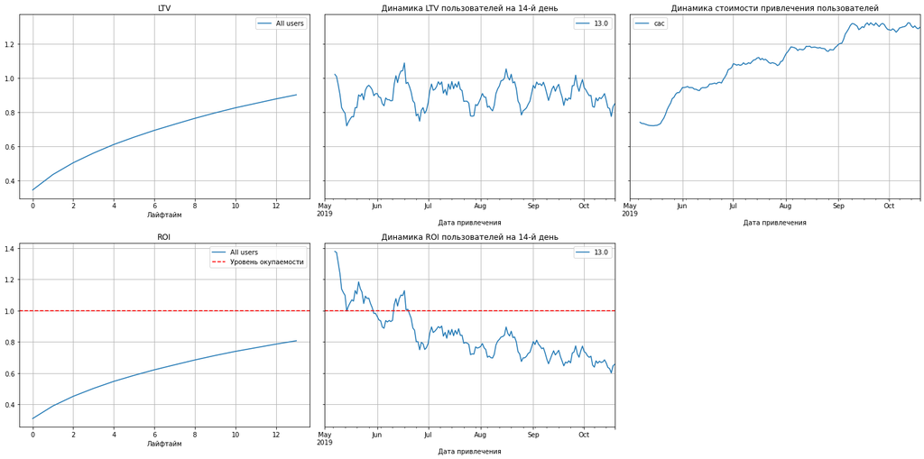

```python
# Расчитываем
ltv_raw, ltv_grouped, ltv_history, roi_grouped, roi_history = get_ltv(profiles, orders, observation_date, horizon_days)

# Визуализируем
plot_ltv_roi(ltv_grouped, ltv_history, roi_grouped, roi_history, horizon_days)
```

**Выводы**:

1. Реклама не окупается: значение ROI в конце 14-ти дневного периода — чуть более 80%;
2. При относительно стабильной динамике LTV, динамика САС растёт с мая по конец октября;
3. Динамика стоимости привлечения растёт - растёт и рекламный бюджет;  
   **NB!** Динамика ROI за лайфтайм падает. Общее ROI тоже падаёт со временем.

### Анализ окупаемости рекламы в разбивке по рекламным каналам

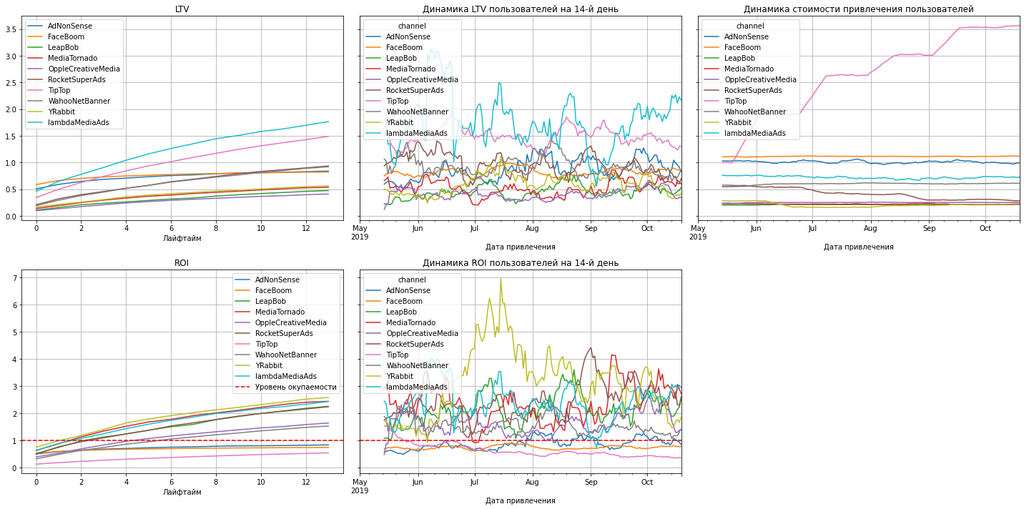

```python
# Расчитаем окупаемость с разбивкой по каналам
ltv_raw, ltv_grouped, ltv_history, roi_grouped, roi_history = get_ltv(
    profiles, orders, observation_date, horizon_days, dimensions=['channel'])

# И визуализируем
plot_ltv_roi(
    ltv_grouped, ltv_history, roi_grouped, roi_history, horizon_days, window=14)
```

**Выводы:**

1. Окупаются почти все каналы привлечения, кроме TipTop, FaceBoom, AdNonSense;
2. Вместе с тем CAC для канала TipTop растёт. Наблюдаем цикличность: 2 недели растёт, 2 недели плато;
3. У канала YRabbit наблюдаем резкий скачок динамики ROI с начала июля по середину июля. **NB!** Что бы понять почему - необходимы дополнительные данные и понимание ситуации.

### Анализ окупаемости рекламы в разбивке по странам

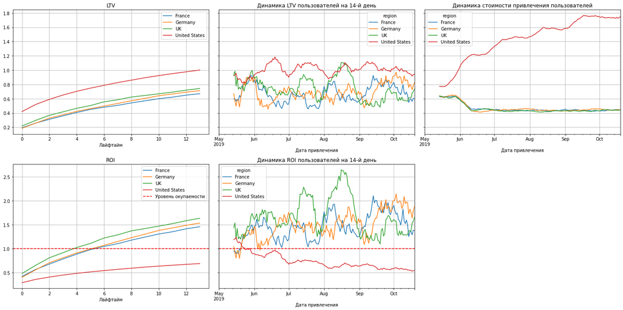

```python
# Расчитаем окупаемость с разбивкой по странам
ltv_raw, ltv_grouped, ltv_history, roi_grouped, roi_history = get_ltv(
    profiles, orders, observation_date, horizon_days, dimensions=['region'])

# И визуализируем
plot_ltv_roi(
    ltv_grouped, ltv_history, roi_grouped, roi_history, horizon_days, window=14)
```

**Выводы:**

1. Пользователи из США не окупают инвестиции в рекламу, в отличии от Фрации, Германии и Великобритании;
2. Каждые 2 недели у пользователей из США наблюдается нисходящая динамика ROI;
3. Стоимость привлечения пользователей США растёт со временем.  
   **NB!** Необходимо более подробно изучить с чем связано отличие показателей из США, от пользоватетй из других стран.

```python
# Выберем только пользователй из США
profiles_usa = profiles.query('region == "United States"')
# Посмотрим среднее и меданное значений цены привлечения пользователей из США
profiles_usa['acquisition_cost'].describe()
```

```
count    61829.000000
mean         1.470646
std          1.047938
min          0.124615
25%          1.081743
50%          1.116176
75%          1.950667
max          3.715385
Name: acquisition_cost, dtype: float64
```

```python
# Для сравнения среднее и меданное значений цены привлечения пользователей НЕ из США
profiles_not_usa = profiles.query('region != "United States"')
profiles_not_usa['acquisition_cost'].describe()
```

```
count    31740.000000
mean         0.459001
std          0.277084
min          0.162273
25%          0.218235
50%          0.257353
75%          0.613953
max          1.312500
Name: acquisition_cost, dtype: float64
```

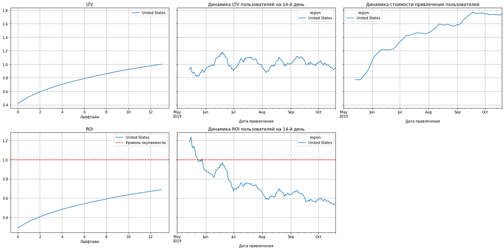

```python
# Расчитаем окупаемость отдельно для США
ltv_raw, ltv_grouped, ltv_history, roi_grouped, roi_history = get_ltv(
    profiles_usa, orders, observation_date, horizon_days, dimensions=['region'])

# И визуализируем
plot_ltv_roi(
    ltv_grouped, ltv_history, roi_grouped, roi_history, horizon_days, window=14)
```

### Анализ окупаемости рекламы в разбивке устройств (платформ)

По условиям задания это не трубуется, но интересно посмотреть может есть какие инсаты

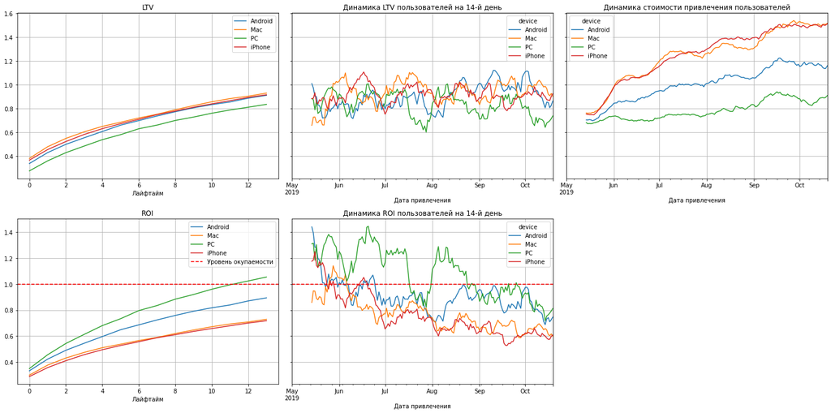

```python
# Расчитаем окупаемость с разбивкой по устройствам
ltv_raw, ltv_grouped, ltv_history, roi_grouped, roi_history = get_ltv(
    profiles, orders, observation_date, horizon_days, dimensions=['device'])

# И визуализируем
plot_ltv_roi(
    ltv_grouped, ltv_history, roi_grouped, roi_history, horizon_days, window=14)
```

**Выводы**

1. Стоимость привлечения пользователей платформ Apple(Iphone, Mac) растёт быстрее чем у других платформ;
2. Только РС правышает уровень окупаемости (немного), остальные платформы - не окупат инвестиции;
3. Динамика ROI падает относительно САС у всех платформ.

### Промежуточные выводы

1. Реклама не окупается: значение ROI в конце 14-ти дневного периода — чуть более 80%;
2. Динамика стоимости привлечения растёт - растёт и рекламный бюджет;
3. Динамика ROI за лайфтайм падает. Общее ROI тоже падает со временем;
4. Окупаются почти все каналы привлечения, кроме TipTop, FaceBoom, AdNonSense. Вместе с тем CAC для канала TipTop растёт;
5. У канала YRabbit наблюдаем резкий скачок динамики ROI с начала июля по середину июля. Что бы понять почему - необходимы дополнительные данные и понимание ситуации;
6. Пользователи из США не окупают инвестиции в рекламу, в отличии от Франции, Германии и Великобритании;
7. Каждые 2 недели у пользователей из США наблюдается нисходящая динамика ROI;
8. Стоимость привлечения пользователей США растёт со временем;
9. Стоимость привлечения пользователей платформ Apple (Iphone, Mac) растёт быстрее чем у других платформ;
10. Только РС превышает уровень окупаемости (немного), остальные платформы - не окупят инвестиции;
11. Динамика ROI падает относительно САС у всех платформ.

### Графики конверсии и удержания с разбивкой по устройствам, странам, рекламным каналам

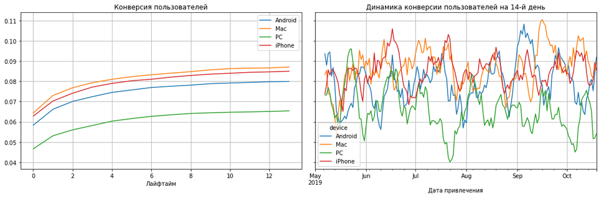

```python
# Расчитаем конверсию с разбивкой по устройствам
conversion_raw, conversion_grouped, conversion_history = get_conversion(
    profiles, orders, observation_date, horizon_days, dimensions=['device'])
# И визуализируем
plot_conversion(conversion_grouped, conversion_history, horizon_days)
```

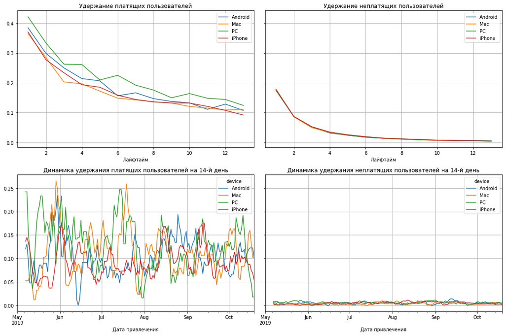

```python
# Расчитаем удержание с разбивкой по устройствам
retention_raw, retention_grouped, retention_history = get_retention(
    profiles, visits, observation_date, horizon_days, dimensions=['device'])

# И визуализируем
plot_retention(retention_grouped, retention_history, horizon_days)
```

**Вывод** Ожидаемо удержание пользователей на всех платформах снижается по лафтайму, как у плятящих, так и у неплатящих пользоватей. У вторых сильней, но это тоже ожидаемо.

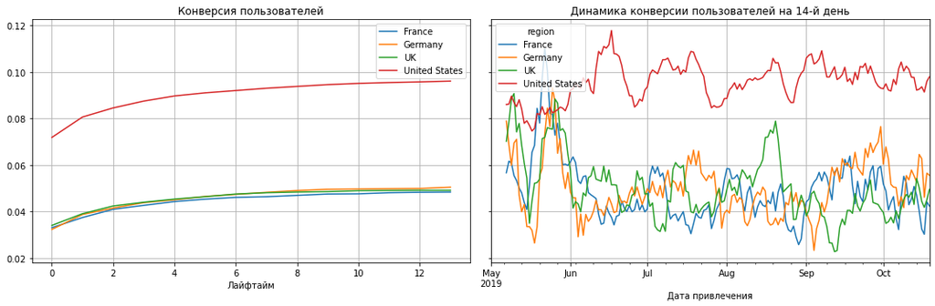

```python
# Расчитаем конверсию с разбивкой по странам
conversion_raw, conversion_grouped, conversion_history = get_conversion(
    profiles, orders, observation_date, horizon_days, dimensions=['region'])
# И визуализируем
plot_conversion(conversion_grouped, conversion_history, horizon_days)
```

**Вывод** Конверсия пользователей из США выше чем из других стран, как по лайфтайму, так и в динамике.

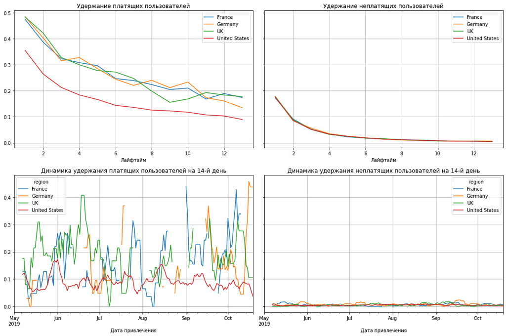

```python
# Расчитаем удержание с разбивкой по странам
retention_raw, retention_grouped, retention_history = get_retention(
    profiles, visits, observation_date, horizon_days, dimensions=['region'])

# И визуализируем
plot_retention(retention_grouped, retention_history, horizon_days)
```

**Вывод** Но, у пользователей из США плохое удержание платящих пользователей, хуже чем у пользоватей из других стран.  
**NB!** В данных пользователей из Германии, Франции и Великобритании есть пробелы - данные неполные.

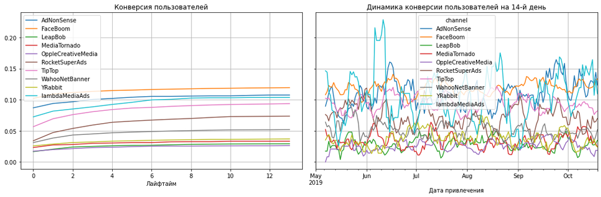

```python
# Расчитаем конверсию с разбивкой по рекламным каналам
conversion_raw, conversion_grouped, conversion_history = get_conversion(
    profiles, orders, observation_date, horizon_days, dimensions=['channel'])
# И визуализируем
plot_conversion(conversion_grouped, conversion_history, horizon_days)
```

**Вывод** У ряда минорных каналов уровень конверсии совсем небольшой, но затратны на них невелики.

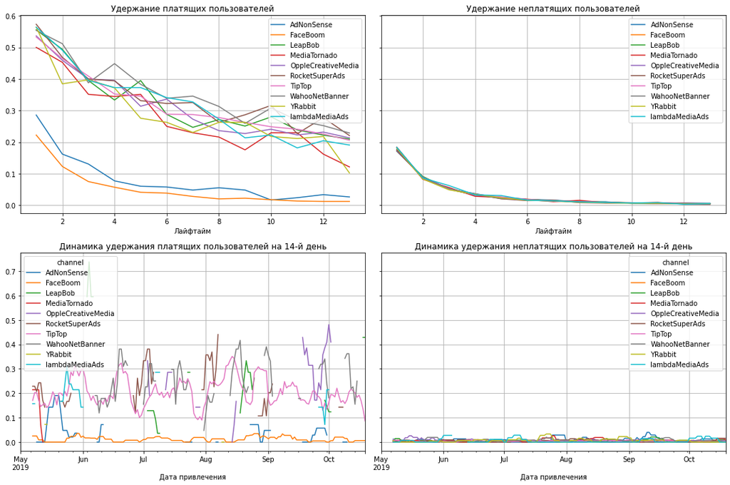

```python
# Расчитаем удержание с разбивкой по рекламным каналам
retention_raw, retention_grouped, retention_history = get_retention(
    profiles, visits, observation_date, horizon_days, dimensions=['channel'])

# И визуализируем
plot_retention(retention_grouped, retention_history, horizon_days)
```

**Вывод!!!** У каналов, на которые тратится значительная доля бюджета, FaceBoom и AdNotSense низкое удержание платных пользователей.  
**NB!** В данных также есть пробелы.

### Выводы по разделу

Анализ окупаемости позвоялет сделать следующие **выводы:**

1. Польностью вложения в рекламу не окупаются;
2. В разрезе устройст хуже окупаются устройства Iphone и Mac;
3. В разрезе стран - США не окупает вложения в рекламу;
4. Каналы привлечения TipTop, FaceBoom, AdNonSense - не окупают вложения.

**NB!** Доисследуем окупаемость (а вернее неокупаемость) каналов в разрезах 'страна-канал' и 'платформа-канал'

```python
# Создадим сводную таблицу
region_channel = profiles.pivot_table(index='region', columns='channel', values='acquisition_cost', aggfunc='sum').fillna(0).round(0)
display(region_channel)
```

| channel region | AdNonSense | FaceBoom | LeapBob | MediaTornado | OppleCreativeMedia | RocketSuperAds | TipTop | WahooNetBanner | YRabbit | lambdaMediaAds |
| --- | --- | --- | --- | --- | --- | --- | --- | --- | --- | --- |
| France | 1376.0 | 0.0 | 628.0 | 0.0 | 747.0 | 0.0 | 0.0 | 1789.0 | 0.0 | 535.0 |
| Germany | 1229.0 | 0.0 | 530.0 | 0.0 | 641.0 | 0.0 | 0.0 | 1553.0 | 0.0 | 471.0 |
| UK | 1306.0 | 0.0 | 640.0 | 0.0 | 763.0 | 0.0 | 0.0 | 1809.0 | 0.0 | 551.0 |
| United States | 0.0 | 32446.0 | 0.0 | 954.0 | 0.0 | 1833.0 | 54751.0 | 0.0 | 944.0 | 0.0 |

**Вывод** Каналы, на которые тратится большая доля рекламного бюджета, FaceBoom и TipTop работают на США, но у пользоватей из США плохое удержание платящих пользователей.

```python
region_channel = profiles.pivot_table(index='device', columns='channel', values='acquisition_cost', aggfunc='sum').fillna(0).round(0)
display(region_channel)
```

| channel device | AdNonSense | FaceBoom | LeapBob | MediaTornado | OppleCreativeMedia | RocketSuperAds | TipTop | WahooNetBanner | YRabbit | lambdaMediaAds |
| --- | --- | --- | --- | --- | --- | --- | --- | --- | --- | --- |
| Android | 1119.0 | 6541.0 | 542.0 | 193.0 | 631.0 | 383.0 | 10862.0 | 1552.0 | 190.0 | 448.0 |
| Mac | 413.0 | 8088.0 | 185.0 | 242.0 | 221.0 | 466.0 | 13550.0 | 515.0 | 239.0 | 175.0 |
| PC | 1577.0 | 3349.0 | 715.0 | 99.0 | 874.0 | 190.0 | 5681.0 | 2053.0 | 104.0 | 621.0 |
| iPhone | 802.0 | 14467.0 | 356.0 | 420.0 | 425.0 | 794.0 | 24658.0 | 1032.0 | 411.0 | 314.0 |

**Вывод** в резрезе платформ таких 'ярких' инсайтов нет.

## Общие выводы и рекомендации для отдела маркетинга

**Общие выводы:**

1. Привлечение пользоватей неэффективно;
2. Причинамы неэффективности привлечения пользователей:
- вложения в канал TipTop (более половины рекламного бюджета) не окупаются;
- вложения в канал FaceBoom (почти 31% бюджета) также не окупаются;
- эти каналы привлечения используется только в США -> пользователи США не рентабельны -> rомпания теряет пользователей в этом регионе;
1. Пользователи платформ Apple, а это скорее всего тоже в большинстве жители США, не окупаются, относительно вложенной рекламы в платформы Apple.